# Ejercicio Guiado N°7 - Análisis de Datos y Estadística Computacional

- Mostrar todo el código
- Ocultar todo el código
- Ver el código fuente

Regresión Múltiple: dummies, interacciones, cuadráticos y robustez

Autor/a

Afiliación

Prof. Gabriel Duarte Zúñiga

Universidad Adolfo Ibáñez | DIAPP-2026

Fecha de publicación

7 de julio de 2026

**Antes de comenzar**

Esta guía usa los mismos paquetes “modernos” que vimos en clase. Si es la primera vez, instálalos (una sola vez):

**Código**

```r
install.packages(c(
  "tidyverse",      # manipulación y gráficos
  "easystats",      # parameters, performance, see, report
  "sjPlot",         # tab_model(), plot_model()
  "ggeffects",      # ggpredict()
  "estimatr",       # lm_robust()
  "marginaleffects",# plot_slopes()
  "broom",          # tidy(), glance()
  "moderndive",     # geom_parallel_slopes()
  "modelsummary",   # tablas comparativas
  "wooldridge"      # datasets
))
```

Luego cárgalos al inicio de tu sesión:

**Código**

```r
library(tidyverse)
library(easystats)
library(sjPlot)
library(ggeffects)
library(estimatr)
library(marginaleffects)
library(broom)
library(moderndive)
library(modelsummary)
library(wooldridge)
```

# Ejercicio Grupal

Seguiremos con el dataset **`hprice1`** (Wooldridge) de la guía anterior: **88 viviendas** con su precio de venta y características. Ahora aplicaremos **regresión múltiple** para responder preguntas más ricas: ¿importa el **estilo** de la casa?, ¿el efecto del tamaño **difiere** según el estilo?, ¿el terreno tiene **rendimientos decrecientes**?

| Variable | Descripción |
| --- | --- |
| `price` | Precio de venta (en **miles** de USD) |
| `sqrft` | Superficie construida (**pies cuadrados**) |
| `bdrms` | Número de dormitorios |
| `lotsize` | Tamaño del terreno (pies cuadrados) |
| `colonial` | **1** si la casa es de estilo colonial, **0** si no |
| `lprice` | Logaritmo natural de `price` |

> ⏱️ Objetivo: resolver la guía en unos **30-40 minutos**. Intente primero cada pregunta y antes de desplegar la **Pauta**.

### Pregunta 1: Cargar los datos y preparar la dummy

Cargue `hprice1` en un objeto llamado `casas`. Convierta `colonial` en un **factor** con etiquetas `"No colonial"` (0) y `"Colonial"` (1), guardándolo en el mismo objeto. Verifique con `count()` cuántas casas hay de cada tipo.

**Pauta**

**Código**

```r
casas <- hprice1 |>
  mutate(colonial = factor(colonial, labels = c("No colonial", "Colonial")))

casas |> count(colonial)
```

| colonial | n |
| --- | --- |
| No colonial | 27 |
| Colonial | 61 |

Hay **27** casas no coloniales y **61** coloniales. Al convertir `colonial` en factor, R tomará **“No colonial”** como **grupo de referencia** (*benchmark*): los coeficientes se interpretarán **respecto a** ese grupo.

### Pregunta 2: Regresión con una dummy

Estime `price` en función de `colonial` y guárdelo en `m1`. Muestre los resultados con `model_parameters()`. **Interprete** el intercepto y el coeficiente de `colonial`. ¿Es la diferencia estadísticamente significativa?

**Pauta**

**Código**

```r
m1 <- lm(price ~ colonial, data = casas)
model_parameters(m1)
```

| Parameter | Coefficient | SE | CI | CI_low | CI_high | t | df_error | p |
| --- | --- | --- | --- | --- | --- | --- | --- | --- |
| (Intercept) | 272.3704 | 19.69173 | 0.95 | 233.2245 | 311.5162 | 13.831713 | 86 | 1.403915e-23 |
| colonialColonial | 30.5485 | 23.65159 | 0.95 | -16.4693 | 77.5663 | 1.291605 | 86 | 1.999547e-01 |

Con una sola dummy, la regresión **reproduce las medias por grupo**:

- **Intercepto = 272.4**: precio promedio de las casas **no coloniales** (el grupo de referencia), es decir, unos **$272.400**.
- **colonial [Colonial] = 30.5**: las casas coloniales cuestan, en promedio, **$30.500 más** (272.4 + 30.5 = 302.9).

Sin embargo, el **p-value ≈ 0.20** (> 0.05): la diferencia **no** es estadísticamente significativa. En la muestra las coloniales son más caras, pero no tenemos evidencia suficiente para afirmar que eso ocurre en la población.

### Pregunta 3: Agregar controles (regresión múltiple)

Estime ahora `price ~ colonial + sqrft + bdrms` y guárdelo en `m2`. Compare `m1` y `m2` con `tab_model()`. **Interprete** el coeficiente de `sqrft` *ceteris paribus* y explique **qué le pasó** al coeficiente de `colonial`.

**Pauta**

**Código**

```r
m2 <- lm(price ~ colonial + sqrft + bdrms, data = casas)

tab_model(m1, m2, show.reflvl = TRUE, show.intercept = TRUE,
          p.style = "numeric_stars")
```

|  | price |  |  | price |  |  |
| --- | --- | --- | --- | --- | --- | --- |
| Predictors | Estimates | CI | p | Estimates | CI | p |
| (Intercept) | 272.37 *** | 233.22 – 311.52 | **<0.001** | -21.55 | -83.62 – 40.51 | 0.492 |
| bdrms |  |  |  | 12.49 | -7.45 – 32.42 | 0.216 |
| No colonial | *Reference* |  |  | *Reference* |  |  |
| Colonial | 30.55 | -16.47 – 77.57 | 0.200 | 13.08 | -17.62 – 43.77 | 0.399 |
| sqrft |  |  |  | 0.13 *** | 0.10 – 0.16 | **<0.001** |
| Observations | 88 |  |  | 88 |  |  |
| R<sup>2</sup> / R<sup>2</sup> adjusted | 0.019 / 0.008 |  |  | 0.635 / 0.622 |  |  |
| * p<0.05 ** p<0.01 *** p<0.001 |  |  |  |  |  |  |

- **`sqrft` = 0.130**: por cada **pie cuadrado adicional**, el precio sube en promedio **$130** (0.130 miles), **manteniendo constantes** el estilo y el número de dormitorios (*ceteris paribus*). Es altamente significativo.
- **`colonial`** cae de **30.5** a **13.1** (y sigue sin ser significativo): buena parte de la “prima colonial” bruta se debía a que las casas coloniales tienden a ser **más grandes**. Al **controlar por tamaño**, esa diferencia se reduce mucho.

Esto ilustra la lógica *ceteris paribus*: controlar por las variables correctas cambia lo que un coeficiente significa.

### Pregunta 4: ¿El efecto del tamaño difiere por estilo? (interacción)

Estime `price ~ colonial * sqrft` y guárdelo en `m3`. Muéstrelo con `model_parameters()` y grafique con `plot_model(type = "pred")`. ¿Qué mide el término de interacción? ¿Es significativo?

**Pauta**

**Código**

```r
m3 <- lm(price ~ colonial * sqrft, data = casas)
model_parameters(m3)
```

| Parameter | Coefficient | SE | CI | CI_low | CI_high | t | df_error | p |
| --- | --- | --- | --- | --- | --- | --- | --- | --- |
| (Intercept) | 28.68131694 | 38.38954241 | 0.95 | -47.66049822 | 105.02313209 | 0.7471128 | 84 | 4.570817e-01 |
| colonialColonial | -29.67416256 | 50.05384332 | 0.95 | -129.21171926 | 69.86339413 | -0.5928448 | 84 | 5.548777e-01 |
| sqrft | 0.12450525 | 0.01859894 | 0.95 | 0.08751922 | 0.16149128 | 6.6942125 | 84 | 2.292316e-09 |
| colonialColonial:sqrft | 0.02456811 | 0.02404813 | 0.95 | -0.02325423 | 0.07239046 | 1.0216226 | 84 | 3.098928e-01 |

**Código**

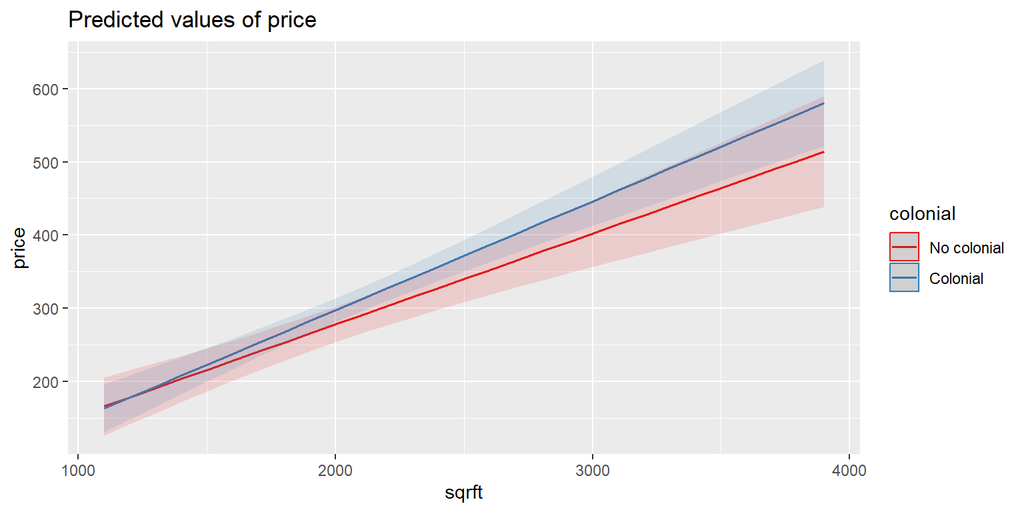

```r
plot_model(m3, type = "pred", terms = c("sqrft", "colonial"))
```

Recuerde: `colonial * sqrft` incluye los efectos principales **más** la interacción; `colonial:sqrft` incluiría **solo** la interacción.

### Pregunta 5: No linealidad — términos cuadráticos

¿Tiene el **terreno** rendimientos decrecientes? Estime `price ~ lotsize + I(lotsize^2)` y guárdelo en `m4`. Grafique el efecto con `plot_model(type = "pred")` y el **efecto marginal** con `plot_slopes()`. Interprete el signo del término cuadrático.

**Pauta**

**Código**

```r
m4 <- lm(price ~ lotsize + I(lotsize^2), data = casas)
model_parameters(m4)
```

| Parameter | Coefficient | SE | CI | CI_low | CI_high | t | df_error | p |
| --- | --- | --- | --- | --- | --- | --- | --- | --- |
| (Intercept) | 1.445912e+02 | 1.907797e+01 | 0.95 | 1.066591e+02 | 1.825233e+02 | 7.578961 | 85 | 3.952936e-11 |
| lotsize | 2.060390e-02 | 2.425137e-03 | 0.95 | 1.578208e-02 | 2.542573e-02 | 8.495974 | 85 | 5.655626e-13 |
| I(lotsize^2) | -2.008196e-07 | 2.689504e-08 | 0.95 | -2.542942e-07 | -1.473450e-07 | -7.466788 | 85 | 6.616091e-11 |

**Código**

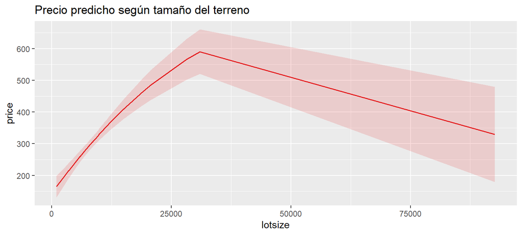

```r
plot_model(m4, type = "pred", terms = "lotsize [all]") +
  labs(title = "Precio predicho según tamaño del terreno")
```

**Código**

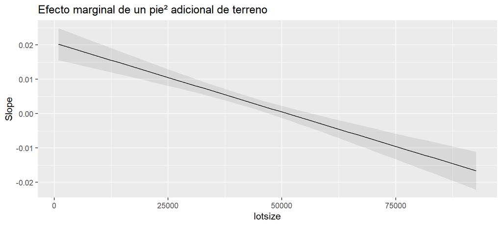

```r
plot_slopes(m4, variables = "lotsize", condition = "lotsize") +
  labs(title = "Efecto marginal de un pie² adicional de terreno")
```

El coeficiente de `lotsize` es **positivo** y el de `I(lotsize^2)` es **negativo** (ambos significativos): el terreno tiene **rendimientos decrecientes**. Cada pie cuadrado adicional aumenta el precio, pero **cada vez menos**. El efecto marginal es $\hat\beta_1 + 2\hat\beta_2 \cdot lotsize$, que **cae** a medida que el terreno crece (la curva del segundo gráfico baja). Dentro del rango habitual de los datos el efecto es **positivo pero decreciente**.

### Pregunta 6: Chequear supuestos

Sobre el modelo `m2` (`price ~ colonial + sqrft + bdrms`), genere el diagnóstico visual con `check_model()` y aplique el test `check_heteroskedasticity()`. ¿Se cumple el supuesto de homocedasticidad?

**Pauta**

**Código**

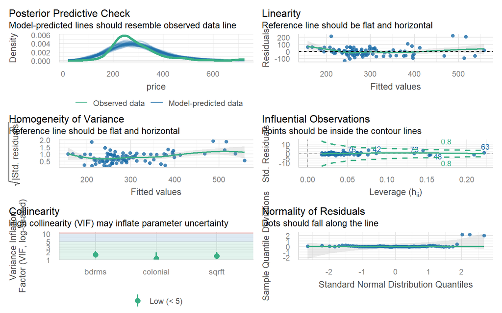

```r
check_model(m2)
```

**Código**

```r
check_heteroskedasticity(m2)
```

[output not shown]

`check_heteroskedasticity()` **detecta heterocedasticidad** (p < 0.05): la varianza de los errores **no** es constante (algo muy común con precios de vivienda, donde las casas caras tienen residuos más dispersos).

**Consecuencia:** los coeficientes MCO siguen siendo **insesgados**, pero sus **errores estándar**, y por lo tanto los p-values e intervalos, quedan **mal calculados**. La inferencia deja de ser confiable tal como está.

### Pregunta 7: Errores estándar robustos

Reestime `m2` con `lm_robust()` (guárdelo en `m2_rob`) y compárelo con el MCO clásico usando `tab_model()`. ¿Qué cambia y qué **no** cambia?

**Pauta**

**Código**

```r
m2_rob <- lm_robust(price ~ colonial + sqrft + bdrms, data = casas)

tab_model(m2, m2_rob,
          dv.labels = c("MCO clásico", "SE robustos (HC2)"),
          show.ci = FALSE, p.style = "numeric_stars")
```

|  | MCO clásico |  | SE robustos (HC2) |  |
| --- | --- | --- | --- | --- |
| Predictors | Estimates | p | Estimates | p |
| (Intercept) | -21.55 | 0.492 | -21.55 | 0.620 |
| colonial [Colonial] | 13.08 | 0.399 | 13.08 | 0.475 |
| sqrft | 0.13 *** | **<0.001** | 0.13 *** | **<0.001** |
| bdrms | 12.49 | 0.216 | 12.49 | 0.226 |
| Observations | 88 |  | 88 |  |
| R<sup>2</sup> / R<sup>2</sup> adjusted | 0.635 / 0.622 |  | 0.635 / 0.622 |  |
| * p<0.05 ** p<0.01 *** p<0.001 |  |  |  |  |

Los **coeficientes son idénticos**: `lm_robust()` **no** cambia las estimaciones puntuales. Lo que cambia son los **errores estándar** (y con ellos p-values y significancia), que ahora son **válidos bajo heterocedasticidad**. Reportar errores robustos es práctica **estándar** con datos de corte transversal como estos.

### Pregunta 8: Transformar la variable dependiente (log)

Estime el mismo modelo de la Pregunta 3 pero con **`log(price)`** como variable dependiente: `lm(log(price) ~ colonial + sqrft + bdrms)`, guárdelo en `m5`. Interprete cómo **cambia** la lectura del coeficiente de `sqrft`. Como bonus, vuelva a correr `check_heteroskedasticity()`. ¿Qué observa?

**Pauta**

**Código**

```r
m5 <- lm(log(price) ~ colonial + sqrft + bdrms, data = casas)
model_parameters(m5)
```

| Parameter | Coefficient | SE | CI | CI_low | CI_high | t | df_error | p |
| --- | --- | --- | --- | --- | --- | --- | --- | --- |
| (Intercept) | 4.7523865722 | 0.0963799799 | 0.95 | 4.5607244125 | 4.9440487320 | 49.3088562 | 84 | 8.713824e-64 |
| colonialColonial | 0.0797285860 | 0.0476674865 | 0.95 | -0.0150634385 | 0.1745206104 | 1.6725989 | 84 | 9.812710e-02 |
| sqrft | 0.0003880581 | 0.0000430711 | 0.95 | 0.0003024065 | 0.0004737097 | 9.0097107 | 84 | 5.672435e-14 |
| bdrms | 0.0123584207 | 0.0309539630 | 0.95 | -0.0491969293 | 0.0739137707 | 0.3992516 | 84 | 6.907211e-01 |

Al usar el **logaritmo del precio**, pasamos a un modelo **log-nivel**: el coeficiente se interpreta en **términos porcentuales** (semi-elasticidad, $100 \times \hat\beta$).

- **`sqrft` = 0.00039**: cada pie cuadrado adicional se asocia con un **+0.039%** en el precio ($100 \times 0.00039$), o ~**3.9% por cada 100 pies cuadrados**. Compare con la Pregunta 3, donde el mismo efecto se leía en **dólares** ($130/pie²).
- **`colonial` ≈ 0.08**: una casa colonial cuesta aproximadamente **8% más**, *ceteris paribus*.

**Bonus:**

**Código**

```r
check_heteroskedasticity(m5)
```

```
OK: Error variance appears to be homoscedastic (p = 0.539).
```

¡La heterocedasticidad **ya no se detecta** (p > 0.05)! Transformar la variable dependiente a logaritmo no solo cambia la **interpretación** a porcentajes: además suele **estabilizar la varianza** de los errores, un motivo frecuente para trabajar con `log()` en variables como precios o salarios.

# Resumen

| Modelo | Sintaxis en R | Idea clave |
| --- | --- | --- |
| Dummy | `price ~ colonial` | Coeficiente = **diferencia de medias** vs. referencia |
| Múltiple | `price ~ colonial + sqrft + bdrms` | Cada coef. es marginal **ceteris paribus** |
| Interacción | `price ~ colonial * sqrft` | El efecto de una variable **depende** de otra |
| Cuadrático | `price ~ lotsize + I(lotsize^2)` | Efecto marginal **no constante** ($\beta_1+2\beta_2 x$) |
| Robustez | `lm_robust(...)` | Corrige SE; **mismos** $\beta$ |
| Log del DV | `log(price) ~ ...` | Coeficientes en **%** (semi-elasticidad) |

**Funciones clave para interpretar y reportar**

`model_parameters()`, `tab_model()`, `plot_model()`, `plot_slopes()`, `check_model()`, `check_heteroskedasticity()`, `lm_robust()` y `modelsummary()`.